# Most Severe Weather Events in the US: Health and Economic Issues

Francisco Marco-Serrano

# Synopsis

Since 1996, year from which we have full information on the current 48 events NOAA is recording major storms and weather events information, there have been 653530 of such events in the US. On average, the type of event most harmful with respect to population health is *Heat Wave*, with a combined average of fatalities and injuries of 70 per recorded event. As per the economic consequences, *HURRICANE/TYPHOON* is the event generating most losses on average, with a 817.20 M$.

# Data Processing

From the U.S. National Oceanic and Atmospheric Administration’s (NOAA) storm database we obtained data on major storms and weather events in the United States, including when and where they occur, as well as estimates of any fatalities, injuries, and property damage since 1950 until November 2011.

We first read the data from the bz2 compressed file. The data is a CSV file containing 902297 rows and 37 variables.

```r
storm.df = read.csv("repdata-data-StormData.csv.bz2")

dim(storm.df)  # how big the data frame is
```

```
## [1] 902297     37
```

```r
str(storm.df)  # which is the structure
```

```
## 'data.frame':    902297 obs. of  37 variables:
##  $ STATE__   : num  1 1 1 1 1 1 1 1 1 1 ...
##  $ BGN_DATE  : Factor w/ 16335 levels "1/1/1966 0:00:00",..: 6523 6523 4242 11116 2224 2224 2260 383 3980 3980 ...
##  $ BGN_TIME  : Factor w/ 3608 levels "00:00:00 AM",..: 272 287 2705 1683 2584 3186 242 1683 3186 3186 ...
##  $ TIME_ZONE : Factor w/ 22 levels "ADT","AKS","AST",..: 7 7 7 7 7 7 7 7 7 7 ...
##  $ COUNTY    : num  97 3 57 89 43 77 9 123 125 57 ...
##  $ COUNTYNAME: Factor w/ 29601 levels "","5NM E OF MACKINAC BRIDGE TO PRESQUE ISLE LT MI",..: 13513 1873 4598 10592 4372 10094 1973 23873 24418 4598 ...
##  $ STATE     : Factor w/ 72 levels "AK","AL","AM",..: 2 2 2 2 2 2 2 2 2 2 ...
##  $ EVTYPE    : Factor w/ 985 levels "   HIGH SURF ADVISORY",..: 834 834 834 834 834 834 834 834 834 834 ...
##  $ BGN_RANGE : num  0 0 0 0 0 0 0 0 0 0 ...
##  $ BGN_AZI   : Factor w/ 35 levels "","  N"," NW",..: 1 1 1 1 1 1 1 1 1 1 ...
##  $ BGN_LOCATI: Factor w/ 54429 levels ""," Christiansburg",..: 1 1 1 1 1 1 1 1 1 1 ...
##  $ END_DATE  : Factor w/ 6663 levels "","1/1/1993 0:00:00",..: 1 1 1 1 1 1 1 1 1 1 ...
##  $ END_TIME  : Factor w/ 3647 levels ""," 0900CST",..: 1 1 1 1 1 1 1 1 1 1 ...
##  $ COUNTY_END: num  0 0 0 0 0 0 0 0 0 0 ...
```

[output cut: 23 more lines]

```r
head(storm.df) # show first few rows
```

```
##   STATE__           BGN_DATE BGN_TIME TIME_ZONE COUNTY COUNTYNAME STATE
## 1       1  4/18/1950 0:00:00     0130       CST     97     MOBILE    AL
## 2       1  4/18/1950 0:00:00     0145       CST      3    BALDWIN    AL
## 3       1  2/20/1951 0:00:00     1600       CST     57    FAYETTE    AL
## 4       1   6/8/1951 0:00:00     0900       CST     89    MADISON    AL
## 5       1 11/15/1951 0:00:00     1500       CST     43    CULLMAN    AL
## 6       1 11/15/1951 0:00:00     2000       CST     77 LAUDERDALE    AL
##    EVTYPE BGN_RANGE BGN_AZI BGN_LOCATI END_DATE END_TIME COUNTY_END
## 1 TORNADO         0                                               0
## 2 TORNADO         0                                               0
## 3 TORNADO         0                                               0
## 4 TORNADO         0                                               0
## 5 TORNADO         0                                               0
## 6 TORNADO         0                                               0
##   COUNTYENDN END_RANGE END_AZI END_LOCATI LENGTH WIDTH F MAG FATALITIES
```

[output cut: 20 more lines]

We make sure the date is formated adequately, and create a new variable (YEAR). Keep only the variables for YEAR, STATE, Event Type, Population Health (FATALITIES plus INJURIES), and Economic Consequences (PROPDMG & PROPDMGEXP for property damages plus CROPDMG & CROPDMGEXP for crop damages).

Only data from 1996 to present is used in the analysis since before not all events were recorded. These are a total of 653530 events.

```r
storm.df$BGN_DATE = as.Date(storm.df$BGN_DATE, format = "%m/%d/%Y %H:%M:%S")
storm.df$YEAR = as.integer(format(storm.df$BGN_DATE, "%Y"))

# subset, to keep only the variables we are interested in
keeps = c("YEAR", "STATE", "EVTYPE", "FATALITIES", "INJURIES", "PROPDMG", "PROPDMGEXP", "CROPDMG", "CROPDMGEXP")
storm.df = storm.df[storm.df$YEAR > 1995 , keeps]

dim(storm.df)
```

```
## [1] 653530      9
```

We clean the event types (NOOA states only 48 types, while the database reflects 985).

```r
# Trim spaces
library(stringr)
storm.df$EVTYPE = str_trim(storm.df$EVTYPE)

# Normalise some events...
pattern = "(THUNDERSTORM|TSTM)"
events.index = grep(pattern, storm.df$EVTYPE)
storm.df$EVTYPE[events.index] = "THUNDERSTORM"

pattern = "(FLOOD)"
events.index = grep(pattern, storm.df$EVTYPE)
storm.df$EVTYPE[events.index] = "FLOOD"
```

We transform PROPDMG and CROPDMG in USD$ according to PROPDMGEXP and CROPDMGEXP (K for thousands, M for millions, B for billions).

```r
# Normalise PROPDMG & CROPDMG according to the EXP variables
# Calculated in millions
pattern = "(K|k)"
exp.index = grep(pattern, storm.df$PROPDMGEXP)
storm.df$PROPDMG[exp.index] = storm.df$PROPDMG[exp.index] * 0.001
exp.index = grep(pattern, storm.df$CROPDMGEXP)
storm.df$CROPDMG[exp.index] = storm.df$CROPDMG[exp.index] * 0.001

pattern = "(M|m)"
exp.index = grep(pattern, storm.df$PROPDMGEXP)
storm.df$PROPDMG[exp.index] = storm.df$PROPDMG[exp.index] * 1
exp.index = grep(pattern, storm.df$CROPDMGEXP)
storm.df$CROPDMG[exp.index] = storm.df$CROPDMG[exp.index] * 1

pattern = "(B|b)"
exp.index = grep(pattern, storm.df$PROPDMGEXP)
storm.df$PROPDMG[exp.index] = storm.df$PROPDMG[exp.index] * 1000
exp.index = grep(pattern, storm.df$CROPDMGEXP)
storm.df$CROPDMG[exp.index] = storm.df$CROPDMG[exp.index] * 1000
```

We group the data adding the four variables of interest per type of event.

```r
# mean of the 1996-2011 period per event
storm.mean = aggregate(cbind(FATALITIES, INJURIES, PROPDMG, CROPDMG) ~ EVTYPE, data = storm.df, FUN="mean")
```

# Results

Show Top 10 events with higher average values for each one of the four variables.

```r
head(storm.mean[order(-storm.mean$FATALITIES),], 10)
```

```
##                   EVTYPE FATALITIES INJURIES    PROPDMG   CROPDMG
## 34         COLD AND SNOW  14.000000 0.000000 0.00000000 0.0000000
## 146  Heavy surf and wind   3.000000 0.000000 0.00000000 0.0000000
## 280           ROUGH SEAS   2.666667 1.666667 0.00000000 0.0000000
## 37          COLD WEATHER   2.000000 0.000000 0.00000000 0.0000000
## 397              TSUNAMI   1.650000 6.450000 7.20310000 0.0010000
## 155           HIGH WATER   1.500000 0.000000 0.00000000 0.0000000
## 167 Hypothermia/Exposure   1.333333 0.000000 0.00000000 0.0000000
## 67        EXCESSIVE HEAT   1.085145 3.859300 0.00466407 0.2973442
## 29          COASTALSTORM   1.000000 0.000000 0.00000000 0.0000000
## 35      Cold Temperature   1.000000 0.000000 0.00000000 0.0000000
```

```r
head(storm.mean[order(-storm.mean$INJURIES),], 10)
```

```
##                     EVTYPE FATALITIES INJURIES      PROPDMG    CROPDMG
## 128              Heat Wave 0.00000000 70.00000 0.000000e+00  0.0000000
## 165      HURRICANE/TYPHOON 0.72727273 14.48864 7.875664e+02 29.6349182
## 458     WINTER WEATHER MIX 0.00000000 11.33333 1.000000e-02  0.0000000
## 109                  GLAZE 0.04761905 10.09524 2.857143e-03  0.0000000
## 233 NON-SEVERE WIND DAMAGE 0.00000000  7.00000 5.000000e-03  0.0000000
## 304            SNOW SQUALL 0.40000000  7.00000 6.000000e-03  0.0000000
## 397                TSUNAMI 1.65000000  6.45000 7.203100e+00  0.0010000
## 393    Torrential Rainfall 0.00000000  4.00000 0.000000e+00  0.0000000
## 67          EXCESSIVE HEAT 1.08514493  3.85930 4.664070e-03  0.2973442
## 213           MIXED PRECIP 0.20000000  2.60000 0.000000e+00  0.0000000
```

```r
head(storm.mean[order(-storm.mean$PROPDMG),], 10)
```

```
##                   EVTYPE  FATALITIES    INJURIES   PROPDMG      CROPDMG
## 165    HURRICANE/TYPHOON 0.727272727 14.48863636 787.56636 2.963492e+01
## 312          STORM SURGE 0.007905138  0.14624506 170.72544 1.976285e-05
## 163            HURRICANE 0.358823529  0.27058824  69.48717 1.612594e+01
## 398              TYPHOON 0.000000000  0.45454545  54.56636 7.500000e-02
## 313     STORM SURGE/TIDE 0.074324324  0.03378378  31.35938 5.743243e-03
## 277       River Flooding 0.000000000  0.20000000  21.23100 5.604000e+00
## 137 Heavy Rain/High Surf 0.000000000  0.00000000  13.50000 1.500000e+00
## 395       TROPICAL STORM 0.083577713  0.49560117  11.20598 9.937111e-01
## 65    Erosion/Cstl Flood 0.000000000  0.00000000   8.10000 0.000000e+00
## 43       DAMAGING FREEZE 0.000000000  0.00000000   8.00000 0.000000e+00
```

```r
head(storm.mean[order(-storm.mean$CROPDMG),], 10)
```

```
##                  EVTYPE FATALITIES     INJURIES     PROPDMG   CROPDMG
## 61          Early Frost  0.0000000  0.000000000   0.0000000 42.000000
## 165   HURRICANE/TYPHOON  0.7272727 14.488636364 787.5663636 29.634918
## 42      Damaging Freeze  0.0000000  0.000000000   0.0000000 17.065000
## 163           HURRICANE  0.3588235  0.270588235  69.4871706 16.125941
## 74         Extreme Cold  1.0000000  0.000000000   0.0000000 10.000000
## 5   AGRICULTURAL FREEZE  0.0000000  0.000000000   0.0000000  9.606667
## 277      River Flooding  0.0000000  0.200000000  21.2310000  5.604000
## 49              DROUGHT  0.0000000  0.001644061   0.4299634  5.494273
## 89               Freeze  0.0000000  0.000000000   0.0000000  5.250000
## 399   Unseasonable Cold  0.0000000  0.000000000   0.0000000  5.100000
```

We generate the ‘Population Health’ variable adding FATALITIES and INJURIES, and the ‘Economic Consequences’ variable adding PROPDMG and CROPDMG.

```r
storm.mean$POPHEALTH = storm.mean$FATALITIES + storm.mean$INJURIES
storm.mean$ECONCONS = storm.mean$PROPDMG + storm.mean$CROPDMG
```

Show Top 10 events most harmful for population health and with worst economic consequences.

```r
storm.top10H = storm.mean[order(-storm.mean$POPHEALTH),][1:10, ]
storm.top10H
```

```
##                     EVTYPE  FATALITIES  INJURIES      PROPDMG    CROPDMG
## 128              Heat Wave  0.00000000 70.000000 0.000000e+00  0.0000000
## 165      HURRICANE/TYPHOON  0.72727273 14.488636 7.875664e+02 29.6349182
## 34           COLD AND SNOW 14.00000000  0.000000 0.000000e+00  0.0000000
## 458     WINTER WEATHER MIX  0.00000000 11.333333 1.000000e-02  0.0000000
## 109                  GLAZE  0.04761905 10.095238 2.857143e-03  0.0000000
## 397                TSUNAMI  1.65000000  6.450000 7.203100e+00  0.0010000
## 304            SNOW SQUALL  0.40000000  7.000000 6.000000e-03  0.0000000
## 233 NON-SEVERE WIND DAMAGE  0.00000000  7.000000 5.000000e-03  0.0000000
## 67          EXCESSIVE HEAT  1.08514493  3.859300 4.664070e-03  0.2973442
## 280             ROUGH SEAS  2.66666667  1.666667 0.000000e+00  0.0000000
##     POPHEALTH     ECONCONS
## 128 70.000000 0.000000e+00
## 165 15.215909 8.172013e+02
## 34  14.000000 0.000000e+00
## 458 11.333333 1.000000e-02
## 109 10.142857 2.857143e-03
## 397  8.100000 7.204100e+00
## 304  7.400000 6.000000e-03
## 233  7.000000 5.000000e-03
## 67   4.944444 3.020083e-01
## 280  4.333333 0.000000e+00
```

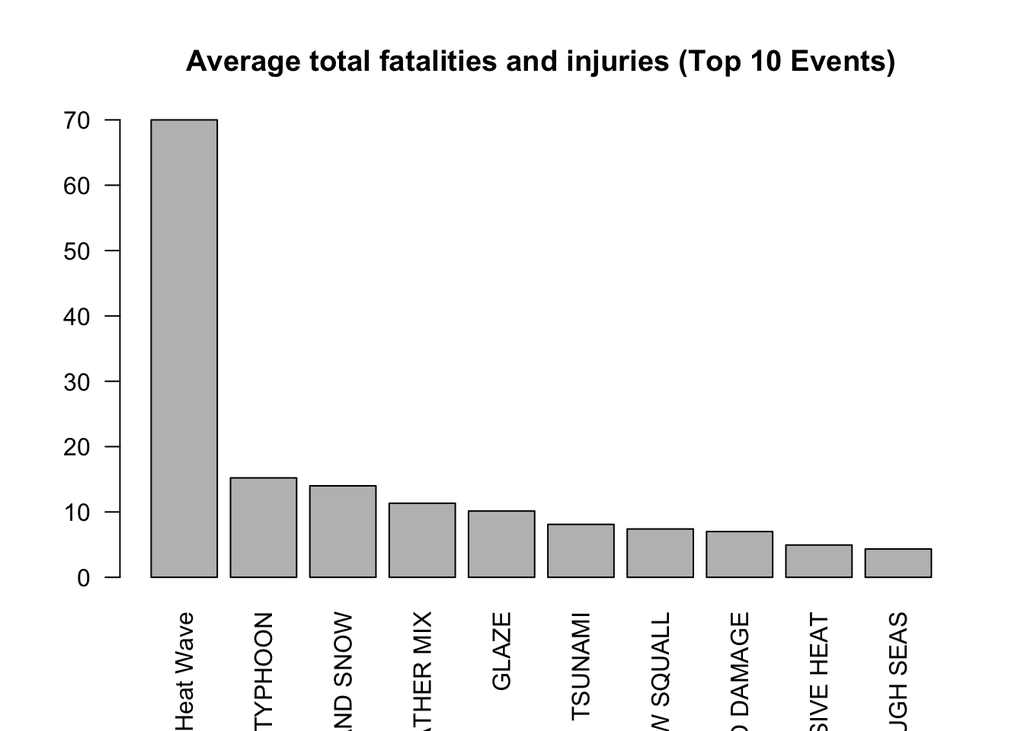

```r
barplot(storm.top10H$POPHEALTH,
        main = "Average total fatalities and injuries (Top 10 Events)",
        names.arg = storm.top10H$EVTYPE, las = 2)
```

```r
storm.top10E = storm.mean[order(-storm.mean$ECONCONS),][1:10, ]
storm.top10E
```

```
##                   EVTYPE  FATALITIES    INJURIES   PROPDMG      CROPDMG
## 165    HURRICANE/TYPHOON 0.727272727 14.48863636 787.56636 2.963492e+01
## 312          STORM SURGE 0.007905138  0.14624506 170.72544 1.976285e-05
## 163            HURRICANE 0.358823529  0.27058824  69.48717 1.612594e+01
## 398              TYPHOON 0.000000000  0.45454545  54.56636 7.500000e-02
## 61           Early Frost 0.000000000  0.00000000   0.00000 4.200000e+01
## 313     STORM SURGE/TIDE 0.074324324  0.03378378  31.35938 5.743243e-03
## 277       River Flooding 0.000000000  0.20000000  21.23100 5.604000e+00
## 42       Damaging Freeze 0.000000000  0.00000000   0.00000 1.706500e+01
## 137 Heavy Rain/High Surf 0.000000000  0.00000000  13.50000 1.500000e+00
## 395       TROPICAL STORM 0.083577713  0.49560117  11.20598 9.937111e-01
##      POPHEALTH  ECONCONS
## 165 15.2159091 817.20128
## 312  0.1541502 170.72546
## 163  0.6294118  85.61311
## 398  0.4545455  54.64136
## 61   0.0000000  42.00000
## 313  0.1081081  31.36512
## 277  0.2000000  26.83500
## 42   0.0000000  17.06500
## 137  0.0000000  15.00000
## 395  0.5791789  12.19969
```

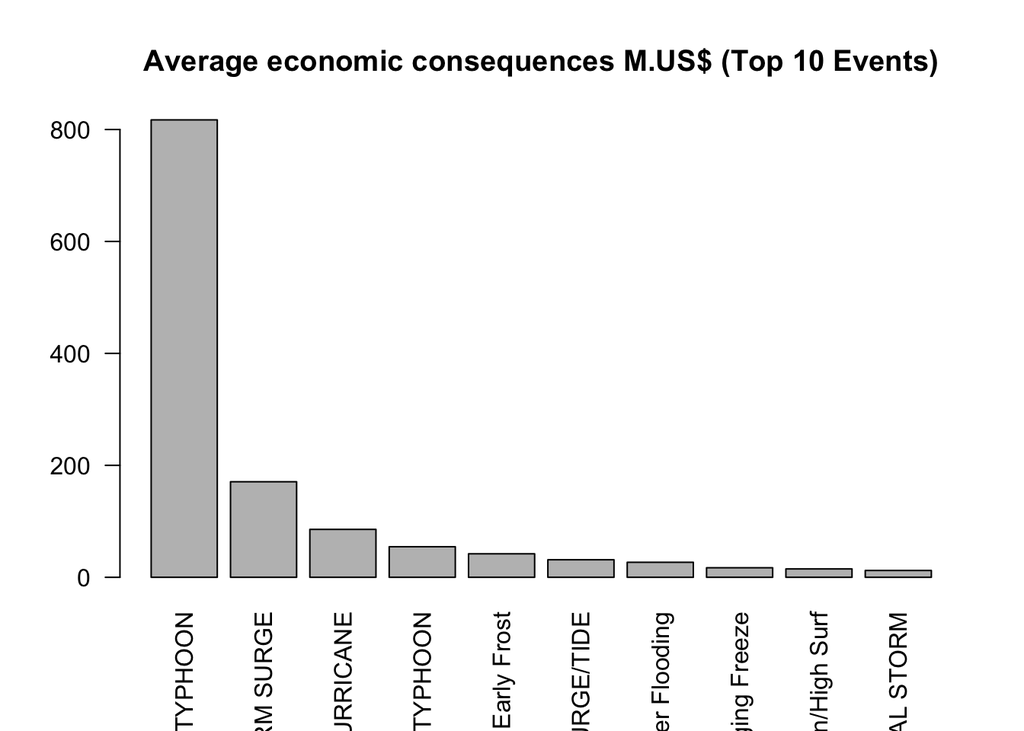

```r
barplot(storm.top10E$ECONCONS,
        main = "Average economic consequences M.US$ (Top 10 Events)",
        names.arg = storm.top10E$EVTYPE, las = 2)
```